# Atividade4

Vanessa Xavier

18/10/2021

## *Byrsonima sericea* DC.

A espécie escolhida para a realização dessa atividade foi a planta *Byrsonima sericea* da família Malpighiaceae. Essa espécie é conhecida popularmente como “murici-da-mata” ou “murici-da-praia”. Trata-se de uma espécie nativa, pioneira e possui hábito arbustivo e arbóreo. Além disso, pode ser encontrada em campos rupestres, florestas ciliares, florestas ombrófilas e restingas (Mamede & Francener, 2015).

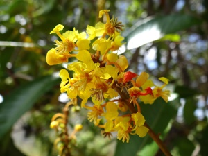

# **ATIVIDADE 4**

O objetivo desta atividade é acessar um banco de dados abertos de ocorrência de espécies (GBIF), resgatar dados referentes à espécie *B. sericea*, inspecioná-los (porque nem tudo que está acessível deve ser 100% confiável), avaliar a qualidade desses dados e, por fim, fazer um mapa demonstrando as ocorrências.

Bom, vamos começar!

## 4.1 Acessando banco de dados abertos

O primeiro passo é acessar o banco de dados abertos através do pacote `tidyverse` para fazer a manipulação dos dados. Esse pacote é formado por um conjunto de pacotes utilizados para manipulação, exploração e visualização de dados.

```r
library(tidyverse)
```

Vamos utilizar, também, o pacote `rgbif` para pesquisar e recuperar dados do GBIF (rede de dados de biodiversidade). O pacote utiliza o código no R em torno da API GBIF para permitir a comunicação entre os dois (R e GBIF), assim dá pra acessar metadados, nome de espécies e ocorrências.

```r
library(rgbif)
```

Além disso, podemos utilizar a função `occ_data` para buscar dados de ocorrência de espécies no repositório do GBIF, através do nome científico, número de identificação, país e outros. Para checar tais funções, temos:

```r
?occ_data
```

Agora vamos baixar as ocorrências sobre a espécie *Byrsonima sericea* a partir de alguns requisitos: ocorrências que possuem coordenadas e que não possuem problemas geoespaciais.

```r
murici_gbif <- occ_data(scientificName = "Byrsonima sericea",
                      hasCoordinate = TRUE,
                      hasGeospatialIssue=FALSE)
```

Precisamos checar as dimensões e verificar o tamanho do dataset.

```r
dim(murici_gbif)
```

```r
dim(murici_gbif$data)
```

```
## [1] 500 111
```

```r
murici_gbif$data %>% names
```

```
##   [1] "key"
##   [2] "scientificName"
##   [3] "decimalLatitude"
##   [4] "decimalLongitude"
##   [5] "issues"
##   [6] "datasetKey"
##   [7] "publishingOrgKey"
##   [8] "installationKey"
##   [9] "publishingCountry"
##  [10] "protocol"
##  [11] "lastCrawled"
##  [12] "lastParsed"
##  [13] "crawlId"
##  [14] "hostingOrganizationKey"
##  [15] "basisOfRecord"
```

[output cut: 96 more lines]

## 4.2 Problemas reportados

O repositório possui um sistema automático que identifica certos problemas com os dados, os chamados “issues”. Para acionar essa função e checar os issues reportados no algoritmo, temos:

```r
gbif_issues()
```

```
##           code                                             issue
## 1          bri                           BASIS_OF_RECORD_INVALID
## 2          ccm                        CONTINENT_COUNTRY_MISMATCH
## 3          cdc                CONTINENT_DERIVED_FROM_COORDINATES
## 4        conti                                 CONTINENT_INVALID
## 5         cdiv                                COORDINATE_INVALID
## 6        cdout                           COORDINATE_OUT_OF_RANGE
## 7        cdrep                            COORDINATE_REPROJECTED
## 8       cdrepf                    COORDINATE_REPROJECTION_FAILED
## 9       cdreps                COORDINATE_REPROJECTION_SUSPICIOUS
## 10     cdround                                COORDINATE_ROUNDED
## 11     cucdmis                       COUNTRY_COORDINATE_MISMATCH
## 12        cudc                  COUNTRY_DERIVED_FROM_COORDINATES
## 13        cuiv                                   COUNTRY_INVALID
## 14         cum                                  COUNTRY_MISMATCH
```

[output cut: 285 more lines]

As ocorrências possuem uma diversidade de issues. Para individualizar e averiguar melhor os issues da listagem recebida, precisamos utilizar o seguinte código:

```r
issues_gbif <- murici_gbif$data$issues %>%
  strsplit(., "[,]") %>%
  unlist() %>%
  unique()
```

Lembrando que o argumento `strsplit` serve para separar mais de um issue na mesma ocorrência e, o argumento `unlist` para transformar tudo em vetor.

É preciso, então, averiguar quais são os problemas/issues no dataset que acabamos de baixar.

```r
gbif_issues() %>%
  data.frame() %>%
  filter(code%in%issues_gbif)
```

```
##        code                                            issue
## 1     conti                                CONTINENT_INVALID
## 2   cdround                               COORDINATE_ROUNDED
## 3     elmms                        ELEVATION_MIN_MAX_SWAPPED
## 4    gass84                     GEODETIC_DATUM_ASSUMED_WGS84
## 5    gdativ                           GEODETIC_DATUM_INVALID
## 6  muluriiv                           MULTIMEDIA_URI_INVALID
## 7   preswcd                      PRESUMED_SWAPPED_COORDINATE
## 8    rdativ                            RECORDED_DATE_INVALID
## 9  txmatfuz                                TAXON_MATCH_FUZZY
## 10    osiic OCCURRENCE_STATUS_INFERRED_FROM_INDIVIDUAL_COUNT
## 11  ambinst                            AMBIGUOUS_INSTITUTION
## 12  colmafu                           COLLECTION_MATCH_FUZZY
## 13  colmano                            COLLECTION_MATCH_NONE
## 14  incomis                  INSTITUTION_COLLECTION_MISMATCH
```

[output cut: 39 more lines]

A maioria dos issues encontrados estão relacionados com discrepancias entre informações indicadas pelos autores e as levantadas pelo algoritmo de checagem, mas por enquanto não apresentam problemas.

Precisamos agora selecionar variáveis interessantes para a validação dos dados como coordenadas, elevação, nome do dataset, etc.

```r
murici_gbif1 <- murici_gbif$data %>%
    dplyr::select(scientificName, acceptedScientificName, decimalLatitude, decimalLongitude,
                  issues, basisOfRecord, occurrenceStatus, rightsHolder,
                  datasetName, recordedBy, continent, locality, habitat, institutionCode, elevation, stateProvince)
```

Foram encontradas 500 ocorrências de 16 variáveis. Entretanto, é possível que existam ocorrências repetidas, então devemos remover essas observações/ocorrências.

```r
murici_gbif1 <- murici_gbif1 %>%
  distinct()
```

Temos agora 476 ocorrências. Precisamos agora checar todos os valores únicos presentes desses dados. Aplica-se, portanto, a função:

```r
lapply(murici_gbif1, unique)
```

```
## $scientificName
## [1] "Byrsonima sericea DC."
##
## $acceptedScientificName
## [1] "Byrsonima sericea DC."
##
## $decimalLatitude
##   [1] -22.930000 -10.183891  -9.709714 -10.184444 -19.284722 -19.647778
##   [7] -18.681667 -18.623056  -9.783056 -11.624172  -9.617778 -18.000000
##  [13] -19.000000 -19.669167 -19.187778 -18.798611 -18.959444 -18.957778
##  [19] -19.481389 -19.698055 -19.191111 -23.004167 -19.189167  -7.275556
##  [25]  -7.278056  -3.793056 -19.651944 -19.697500  -7.363056 -19.191667
##  [31] -19.477500 -19.482500 -19.670000 -14.793639 -19.231667 -19.835278
##  [37] -18.680833 -18.783333 -11.658333 -13.104444 -18.666667 -10.288764
##  [43] -14.213889 -10.406689 -13.456111 -18.621111 -19.479444  -9.652428
```

[output cut: 1044 more lines]

Bom, esses foram os issues já reportados. Mas o que fazer se existirem issues não reportados, e o que fazer para filtrá-los?

## 4.3 Problemas não reportados

É necessário refinar ainda mais as ocorrências, pois podem existir problemas/issues que não foram reportados de forma automática e que podem prejudicar os dados interpretados futuramente. Podemos escolher qual variável podemos selecionar para começar a nossa filtragem. Vamos começar pelas instituições. Lembrando que algumas variáveis, como “locality” nesse caso, podem apresentar inúmeras ocorrências, dificultando a visualização e interpretação do gráfico. Por isso, é necessário explorar essas ocorrências com cada variável, quando possível.

Assim, temos:

```r
murici_gbif1 %>%
  distinct(institutionCode) %>%
  pull()
```

```
##  [1] "JBRJ"
##  [2] "UNIVASF"
##  [3] "IMA"
##  [4] "MBM"
##  [5] "VIES"
##  [6] "Universidade Federal de Mato Grosso"
##  [7] "UNITINS"
##  [8] "UFV"
##  [9] "SAMES"
## [10] "UEFS"
## [11] "Universidade Federal do Ceará"
## [12] "Universidade Tecnológica Federal do Paraná"
## [13] "UFPB"
## [14] "HCF"
## [15] "Universidade Federal de Minas Gerais"
```

[output cut: 43 more lines]

Para melhor visualização das ocorrências por instituição, temos:

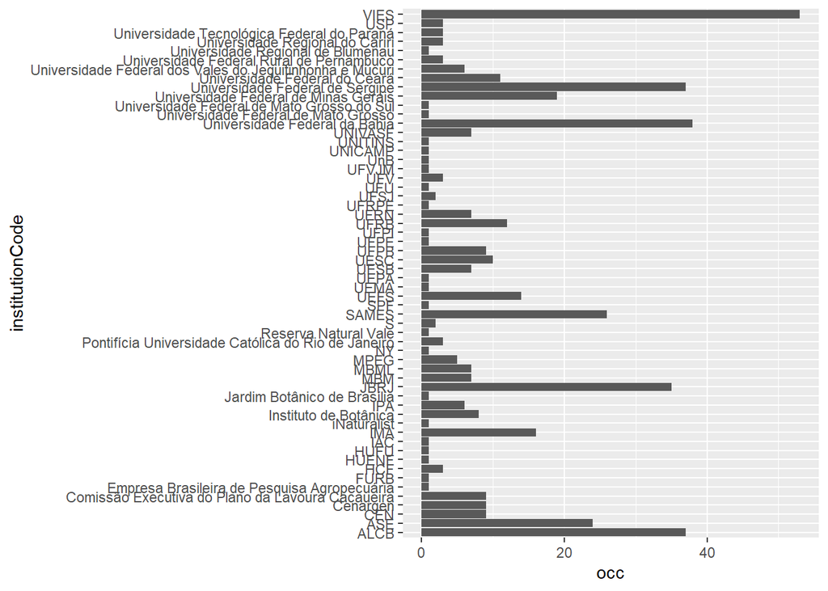

```r
murici_gbif1 %>%
  group_by(institutionCode) %>%
  summarise(occ = length(scientificName)) %>%
  ggplot(aes(occ, y=institutionCode)) +
  geom_bar(stat = 'identity')
```

Observamos muitas instituições e universidades que identificaram a espécie *B. sericea*, e todas as ocorrências estão situadas no Brasil. Algumas instituições possuem muitas ocorrências, então podemos averiguar quantas distinções de datasets existem para essas instituições/universidades. Portanto, escolheremos 5 instituições com maiores quantidades de ocorrências para averiguação:

```r
murici_gbif1 %>%
  filter(institutionCode %in% c("VIES", "Universidade Federal de Sergipe", "Universidade Federal da Bahia", "JBRJ", "ALCB")) %>%
  distinct(datasetName)
```

```
## # A tibble: 6 x 1
##   datasetName
##   <chr>
## 1 RB - Rio de Janeiro Botanical Garden Herbarium Collection
## 2 VIES - Herbário Central da Universidade Federal do Espírito Santo VIES
## 3 <NA>
## 4 ALCB - Herbário Alexandre Leal Costa
## 5 ASE - Herbário da Universidade Federal de Sergipe
## 6 Caatinga Biome - RB - Rio de Janeiro Botanical Garden Herbarium Collection
```

Assim, foram observados que dois datasets se referem à mesma instiuição.

```r
murici_gbif1 %>%
  filter(datasetName %in% c("RB - Rio de Janeiro Botanical Garden Herbarium Collection"))
```

```
## # A tibble: 34 x 16
##    scientificName   acceptedScientif~ decimalLatitude decimalLongitude issues
##    <chr>            <chr>                       <dbl>            <dbl> <chr>
##  1 Byrsonima seric~ Byrsonima serice~          -22.9             -42.6 cdround,~
##  2 Byrsonima seric~ Byrsonima serice~          -23.0             -43.4 cdround,~
##  3 Byrsonima seric~ Byrsonima serice~          -23.0             -43.5 cdround,~
##  4 Byrsonima seric~ Byrsonima serice~          -22.9             -42.5 cdround,~
##  5 Byrsonima seric~ Byrsonima serice~          -22.9             -42.5 cdround,~
##  6 Byrsonima seric~ Byrsonima serice~          -22.9             -42.4 cdround,~
##  7 Byrsonima seric~ Byrsonima serice~          -22.9             -42.5 cdround,~
##  8 Byrsonima seric~ Byrsonima serice~           -4.54            -43.8 gass84,i~
##  9 Byrsonima seric~ Byrsonima serice~           -4.82            -43.0 gass84,i~
## 10 Byrsonima seric~ Byrsonima serice~           -7.02            -44.1 cdround,~
## # ... with 24 more rows, and 11 more variables: basisOfRecord <chr>,
## #   occurrenceStatus <chr>, rightsHolder <chr>, datasetName <chr>,
## #   recordedBy <chr>, continent <chr>, locality <chr>, habitat <chr>,
## #   institutionCode <chr>, elevation <dbl>, stateProvince <chr>
```

Foram observadas 34 ocorrências nesse dataset.

```r
murici_gbif1 %>%
  filter(datasetName %in% c("Caatinga Biome - RB - Rio de Janeiro Botanical Garden Herbarium Collection"))
```

```
## # A tibble: 1 x 16
##   scientificName   acceptedScientifi~ decimalLatitude decimalLongitude issues
##   <chr>            <chr>                        <dbl>            <dbl> <chr>
## 1 Byrsonima seric~ Byrsonima sericea~           -7.09            -39.8 gass84,g~
## # ... with 11 more variables: basisOfRecord <chr>, occurrenceStatus <chr>,
## #   rightsHolder <chr>, datasetName <chr>, recordedBy <chr>, continent <chr>,
## #   locality <chr>, habitat <chr>, institutionCode <chr>, elevation <dbl>,
## #   stateProvince <chr>
```

Já para este dataset, foi observada apenas 1 ocorrência. Isso pode representar uma ambiguidade para a instituição, ao invés de escolherem apenas um dataset. Mas não representa nenhum problema para a interpretação dos nossos dados.

Logo, não irei definir “Caatinga Biome - RB - Rio de Janeiro Botanical Garden Herbarium Collection” como dataset suspeito pois se trata de uma coleta da mesma instituição com apenas a denominação de dataset diferente, ou seja, continua válida. Entretanto, caso queira remover uma ocorrência que identifique como suspeita (por apresentar algum issue não reportado), basta:

```r
murici_gbif_ok <- murici_gbif1 %>%
  filter(!datasetName %in% c("Caatinga Biome - RB - Rio de Janeiro Botanical Garden Herbarium Collection"))
```

Agora, podemos visualizar em um mapa essas ocorrências filtradas para facilitar a nossa interpretação.

```r
library(ggmap)
library(maps)
library(mapdata)
```

```r
world <- map_data('world')
brasil <-map_data('world', region="Brazil")
```

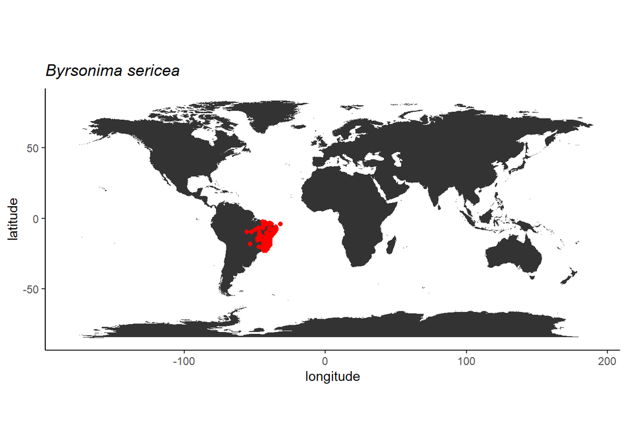

```r
ggplot() +
  geom_polygon(data = world, aes(x = long, y = lat, group = group)) +
  coord_fixed() +
  theme_classic() +
  geom_point(data = murici_gbif_ok, aes(x = decimalLongitude, y = decimalLatitude), color = "red") +
  labs(x = "longitude", y = "latitude", title = expression(italic("Byrsonima sericea")))
```

Podemos utilizar outra variável para verificação. Como por exemplo, elevação por estado.

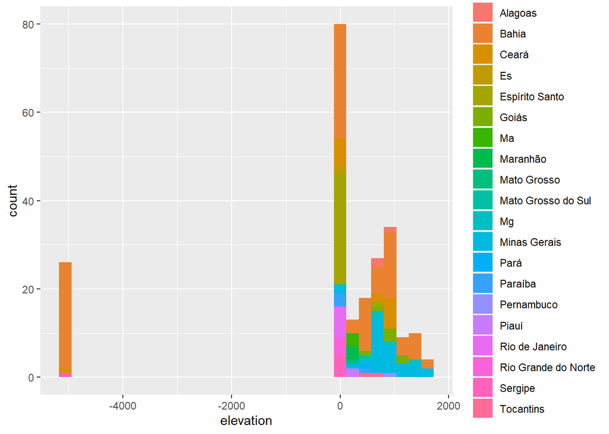

```r
murici_gbif_ok %>%
  ggplot(aes(x = elevation, fill = stateProvince)) +
  geom_histogram()
```

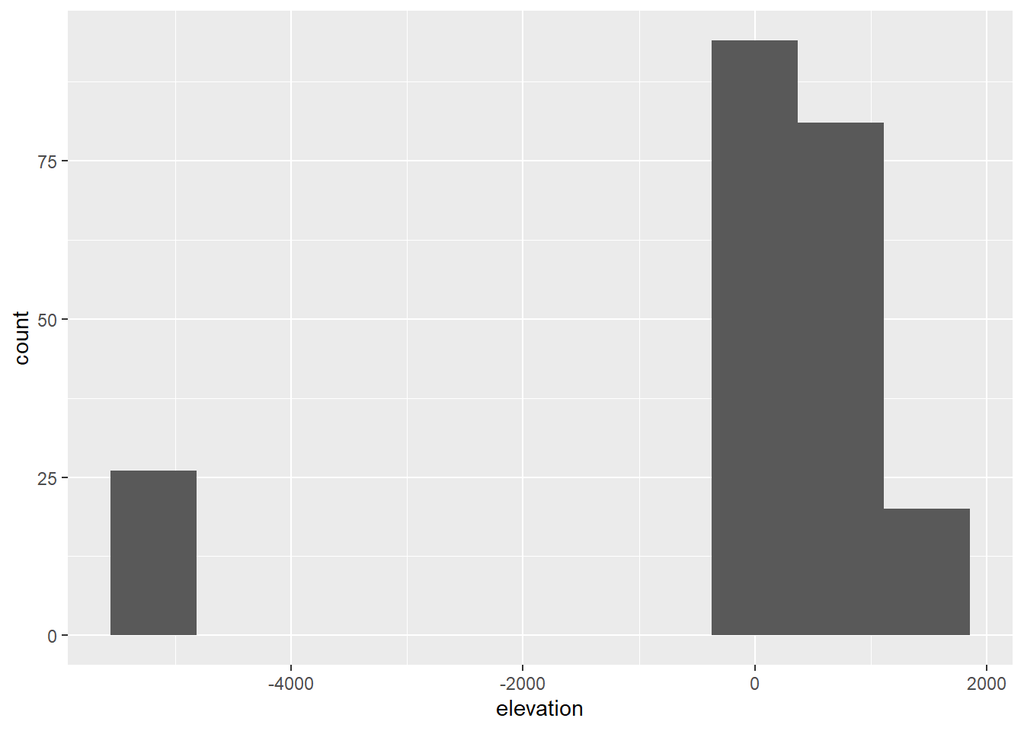

```r
ggplot(murici_gbif_ok, aes(x=elevation)) + geom_histogram(bins=10)
```

A partir deste histograma, vemos que boa parte das ocorrências se concentram a uma elevação entre 0 e 1000 metros. No Rio de Janeiro, por exemplo, a maior distribuição de ocorrências em elevações entre 0 e 1000 metros pode ser explicada pelo relevo e vegetação do estado, isto é, estando presente desde restingas a florestas estacionais (transição entre áreas costeiras e florestas mais adensadas). Mas isso tudo, é claro, são apenas interpretações que necessitam de análises mais minunciosas para serem averiguadas.

Se quisermos diferenciar os pontos por cores no mapa, podemos:

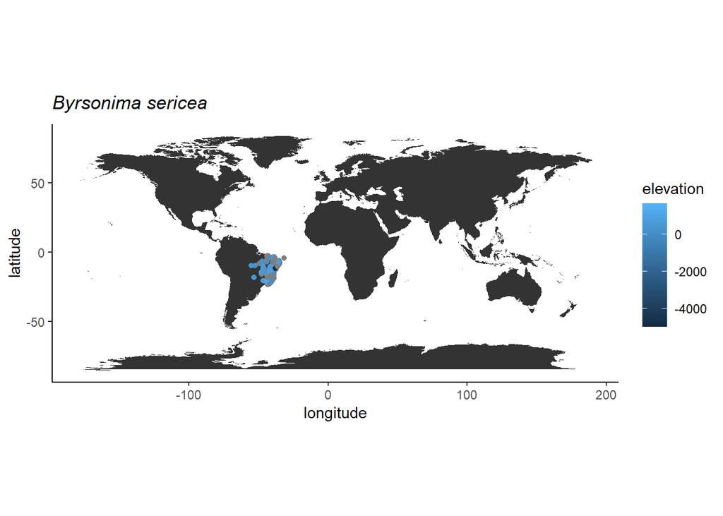

```r
ggplot() +
  geom_polygon(data = world, aes(x = long, y = lat, group = group)) +
  coord_fixed() +
  theme_classic() +
  geom_point(data = murici_gbif_ok, aes(x = decimalLongitude, y = decimalLatitude, color = elevation)) +
  labs(x = "longitude", y = "latitude", title = expression(italic("Byrsonima sericea")))
```

O próximo passo é salvar os dados tratados para economizar tempo no próximo uso.

```r
write.csv(murici_gbif_ok, "C:/Users/vanes/OneDrive/Documentos/UENF/Doutorado - PPGERN/Disciplinas/Ferramentas em ciência colaborativa e bancos de dados abertos/Atividades/Atividade 4/Murici_dados_salvos_ativ4.csv", row.names = FALSE)
```

### 4.3.1 Classificação automática de pontos

#### 4.3.1.1 Utilizando uma função caseira

A quantidade de ocorrências disponíveis no banco de dados abertos podem ser inúmeras e, do mesmo modo, os issues/ problemas existentes também podem ser numerosos. Por isso, podemos usar outras ferramentas para refinar essas ocorrências suspeitas com o auxílio de outros pacotes como veremos abaixo, criando nossas próprias funções:

```r
flag_outlier <- function(df, species)
{dados <- df %>%
    dplyr::filter(scientificName == species);

  dados2 <- geosphere::distVincentyEllipsoid(
    dados %>%
      summarise(centr_lon = median(decimalLongitude),
                centr_lat = median(decimalLatitude)),
    dados %>%
      dplyr::select(decimalLongitude, decimalLatitude)
  ) %>%
    bind_cols(dados) %>%
    rename(dist_centroid = '...1') %>%
    mutate(flag = ifelse(dist_centroid < quantile(dist_centroid, probs = 0.9), "OK",
                         ifelse(dist_centroid >= quantile(dist_centroid, probs = 0.90) & dist_centroid < quantile(dist_centroid, probs = 0.95), "check > Q90",
                                ifelse(dist_centroid >= quantile(dist_centroid, probs = 0.95), "check > Q95", "OK"))))
    print(dados2)}
```

Em outras palavras, a função acima verifica que, ocorrências que ficarem acima de 90% seriam consideradas outliers do centro de distribuição criado pela função. Logo, poderiam ser consideradas como possíveis dados suspeitos. Para classificar essas ocorrências, temos:

```r
marcados <- murici_gbif$data %>%
  data.frame() %>%
  dplyr::select(scientificName, decimalLongitude, decimalLatitude, datasetName) %>%
  distinct() %>%
  flag_outlier(., "Byrsonima sericea DC.")
```

```
##     dist_centroid        scientificName decimalLongitude decimalLatitude
## 1      1090865.78 Byrsonima sericea DC.        -42.58472      -22.930000
## 2       391605.80 Byrsonima sericea DC.        -41.10974      -10.183891
## 3       589261.99 Byrsonima sericea DC.        -35.89673       -9.709714
## 4       505659.90 Byrsonima sericea DC.        -36.49722      -10.184444
## 5       668268.62 Byrsonima sericea DC.        -41.37500      -19.284722
## 6       685360.02 Byrsonima sericea DC.        -39.87583      -19.647778
## 7       578261.29 Byrsonima sericea DC.        -39.74833      -18.681667
## 8       571772.90 Byrsonima sericea DC.        -39.73472      -18.623056
## 9       578261.29 Byrsonima sericea DC.        -39.74833      -18.681667
## 10      571772.90 Byrsonima sericea DC.        -39.73472      -18.623056
## 11     1439258.20 Byrsonima sericea DC.        -52.40278       -9.783056
## 12      215323.47 Byrsonima sericea DC.        -39.06891      -11.624172
## 13      873678.67 Byrsonima sericea DC.        -46.73972       -9.617778
## 14      508995.41 Byrsonima sericea DC.        -39.00000      -18.000000
```

[output cut: 1299 more lines]

Foram observados alguns flags com outliers. Para visualizar melhor, plotamos, então, um mapa:

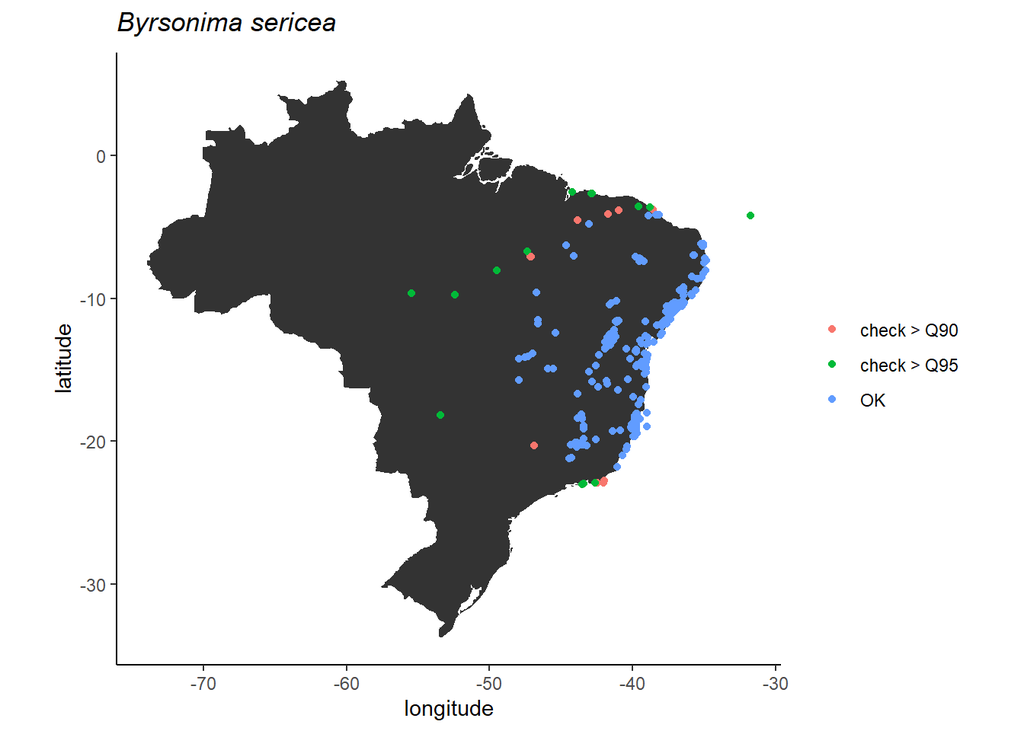

```r
ggplot() +
  geom_polygon(data = brasil, aes(x = long, y = lat, group = group)) +
  coord_fixed() +
  theme_classic() +
  geom_point(data = marcados,
             aes(x = decimalLongitude, y = decimalLatitude,
                 color = flag)) +
  theme(legend.title = element_blank()) +
  labs(x = "longitude", y = "latitude",
       title = expression(italic("Byrsonima sericea")))
```

Pelo mapa plotado, podemos ver que o centro de distribuição da espécie é mesmo na costa (por ex. pode ser em restingas), enquanto que, muito mais ao interior (por ex. Mato Grosso) ou nas extremidades da distribuição, os dados começam a passar o percentil de 95%.

#### 4.3.1.2 Pacote `scrubr`

Um outro pacote que podemos utilizar para o refinamento de ocorrências suspeitas é o `scrubr`. Nele conseguimos reportar problemas com coordenadas com elementos faltantes (`coord_incomplete`), coordenadas impossíveis (`coord_impossible`) e coordenadas duplicadas (`dedup`), por exemplo.

```r
library(scrubr)

data_scrubr <- marcados %>%
  dframe() %>%
  coord_impossible() %>% #coordenadas impossíveis
  coord_incomplete() %>% #coordenadas incompletas
  coord_unlikely() %>% #coordenadas improváveis
  dedup() #coordenadas duplicadas
```

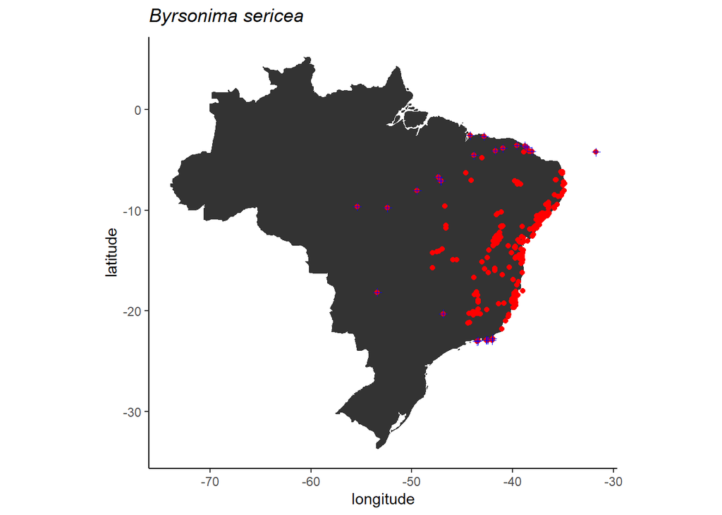

```r
ggplot() +
  geom_polygon(data = brasil, aes(x = long, y = lat, group = group)) +
  coord_fixed() +
  theme_classic() +
  geom_point(data = data_scrubr,
             aes(x = decimalLongitude, y = decimalLatitude),
             color = "red") +
  geom_point(data = marcados %>%
               filter(flag != "OK"),
             aes(x = decimalLongitude, y = decimalLatitude),
             color = "blue", shape = 3) +
  theme(legend.title = element_blank()) +
  labs(x = "longitude", y = "latitude",
       title = expression(italic("Byrsonima sericea")))
```

#### 4.3.1.3 Pacote `CoordinateCleaner`

Um outro pacote que podemos utilizar para refinar ocorrências com problemas, é o `CoordinateCleaner`. Esse pacote coloca flags em ocorrências que potencialmente possuem coordenadas com problemas.

```r
library(CoordinateCleaner)

flags <- clean_coordinates(
    x = marcados,
    lon = "decimalLongitude",
    lat = "decimalLatitude",
    species = "scientificName",
    tests = c("equal", "gbif",
              "zeros", "seas"))
```

Assim, não foram encontradas ocorrências com problemas de coordenadas iguais, zeradas, por exemplo. Mas foram observados 46 registros suspeitos para “seas”.

```r
summary(flags)
```

```
##     .val     .equ     .zer     .sea     .gbf .summary
##        0        0        0       46        0       46
```

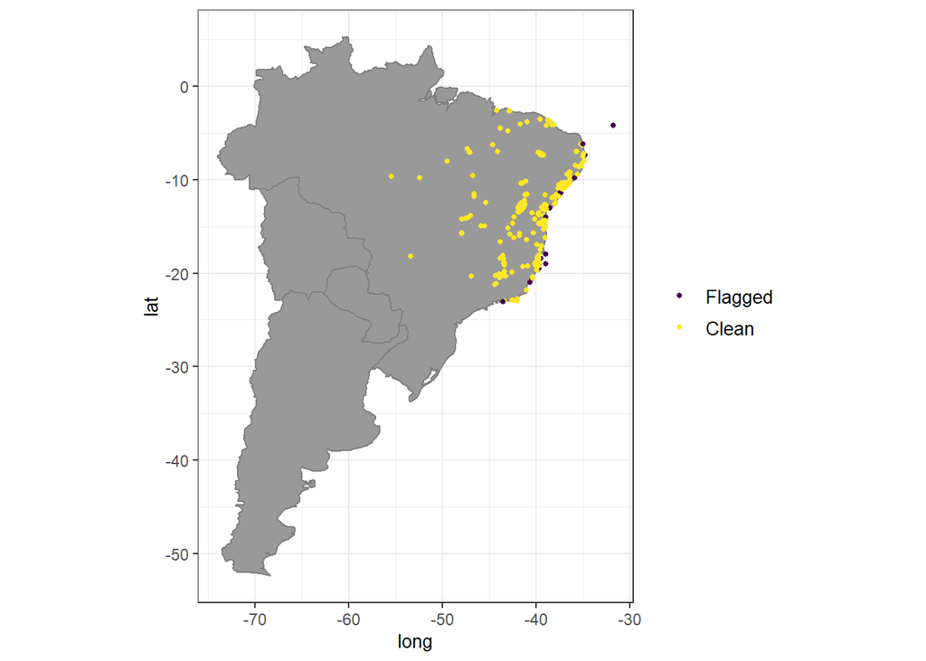

```r
plot(flags, lon = "decimalLongitude", lat = "decimalLatitude")
```

Se quisermos filtrar esses registros, temos:

```r
data_cleaned <- marcados[flags$.summary,]
```

```r
data_flagged <- marcados[!flags$.summary,]
```

Por fim, após a filtragem dos registros com flags (aqueles que possivelmente estão no mar) plotamos o seguinte gráfico:

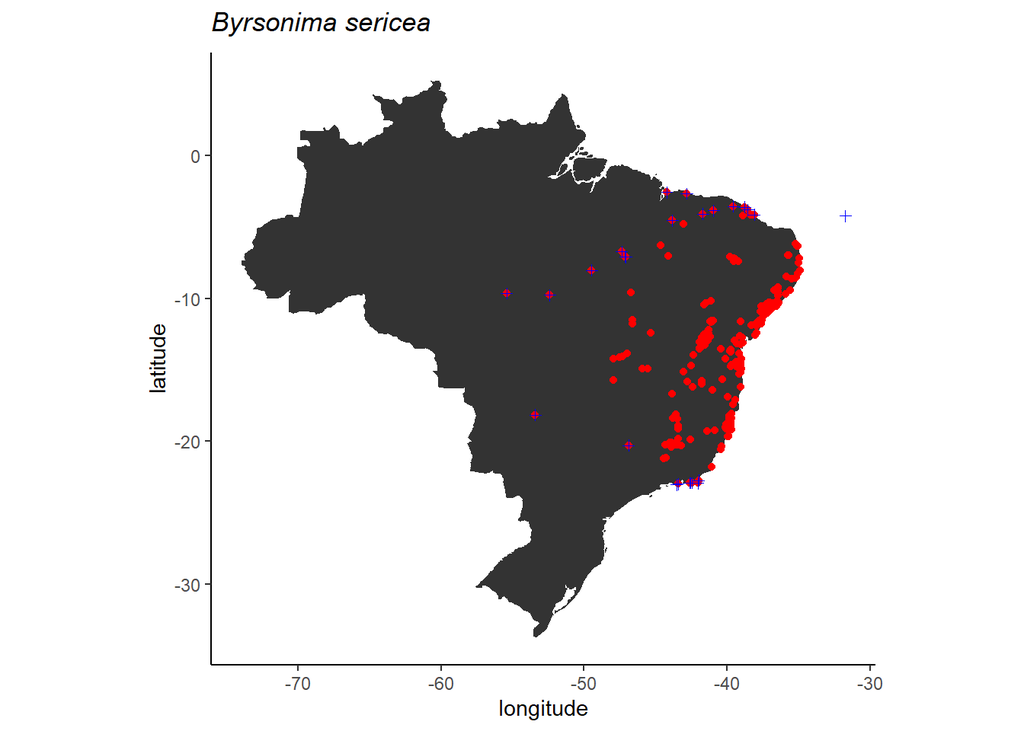

```r
ggplot() +
  geom_polygon(data = brasil, aes(x = long, y = lat, group = group)) +
  coord_fixed() +
  theme_classic() +
  geom_point(data = data_cleaned,
             aes(x = decimalLongitude, y = decimalLatitude),
             color = "red") +
  geom_point(data = marcados %>%
               filter(flag != "OK"),
             aes(x = decimalLongitude, y = decimalLatitude),
             color = "blue", shape = 3) +
  theme(legend.title = element_blank()) +
  labs(x = "longitude", y = "latitude",
       title = expression(italic("Byrsonima sericea")))
```

É possível verificar que essa filtragem mais recente removeu alguns registros que estavam marcados pela filtragem anterior com a função caseira. Desse modo, o refinamento de dados de qualidade pode ser realizado por inúmeros procedimentos. Porém, cabe a nós averiguar se temos ou não que remover todos os dados suspeitos, pois nem sempre isso será necessário.

#### **Referência bibliográfica:**

Mamede, M. C. H., Francener, A. (2015). Byrsonima in Lista de Espécies da Flora do Brasil. Jardim Botânico do Rio de Janeiro. Disponível em: http://floradobrasil.jbrj.gov.br/jabot/floradobrasil/FB8845 (Acesso: outubro de 2021).